# Práctica 2 - Herramientas Exploratorias para Dos o Mas Variables

Jordi Gisbert

# Parte 0: Preparacion de los datos

```r
datos <- read.csv("CURS8990-Codif.csv", fileEncoding = "latin1", strip.white = TRUE)
datos <- datos[, 1:11]
head(datos)
```

```
##     SEXO EDAD MES ESTATURA PESO  POLITICA DIGITO RESIDENCIA TRANSPORTE TIEMPO
## 1 chicos   20   1      183   76 izquierda      5       piso      a pie     15
## 2 chicos   21   6      185   72    centro      8       otra      coche     10
## 3 chicos   22  10      165   75     pasan      8    familia  t publico     30
## 4 chicos   22   4      174   70     pasan      6 residencia      a pie     15
## 5 chicos   22   7      175   70     pasan      7       piso      a pie     20
## 6 chicos   20  11      175   70   derecha      3    familia  compañero     60
##      PROBLEMA
## 1 desigualdad
## 2  terrorismo
## 3 desigualdad
## 4       droga
## 5 desigualdad
## 6     valores
```

```r
cat("Numero de variables:", ncol(datos), "\n")
```

```
## Numero de variables: 11
```

```r
cat("Numero de alumnos:", nrow(datos), "\n")
```

```
## Numero de alumnos: 131
```

```r
cat("Casos completos:", sum(complete.cases(datos)), "\n\n")
```

```
## Casos completos: 131
```

```r
str(datos)
```

```
## 'data.frame':    131 obs. of  11 variables:
##  $ SEXO      : chr  "chicos" "chicos" "chicos" "chicos" ...
##  $ EDAD      : int  20 21 22 22 22 20 22 23 21 21 ...
##  $ MES       : int  1 6 10 4 7 11 7 10 3 6 ...
##  $ ESTATURA  : int  183 185 165 174 175 175 174 159 177 180 ...
##  $ PESO      : int  76 72 75 70 70 70 65 54 72 73 ...
##  $ POLITICA  : chr  "izquierda" "centro" "pasan" "pasan" ...
##  $ DIGITO    : int  5 8 8 6 7 3 7 5 8 5 ...
##  $ RESIDENCIA: chr  "piso" "otra" "familia" "residencia" ...
##  $ TRANSPORTE: chr  "a pie" "coche" "t publico" "a pie" ...
##  $ TIEMPO    : int  15 10 30 15 20 60 5 65 15 15 ...
##  $ PROBLEMA  : chr  "desigualdad" "terrorismo" "desigualdad" "droga" ...
```

Hay datos faltantes en POLITICA (5), TRANSPORTE (2) y PROBLEMA (2). Tenemos 5 variables cualitativas y 6 cuantitativas.

# Parte 1: Analisis cualitativa-cualitativa

## Variables: SEXO y POLITICA

Queremos ver si la tendencia politica tiene algo que ver con el genero del alumno.

### Tabla de contingencia - frecuencias absolutas

```r
datos_sp <- datos[!is.na(datos$SEXO) & !is.na(datos$POLITICA) &
                  datos$SEXO != "" & datos$POLITICA != "", ]

tab_abs <- table(SEXO = datos_sp$SEXO, POLITICA = datos_sp$POLITICA)
addmargins(tab_abs)
```

```
##         POLITICA
## SEXO     centro derecha izquierda pasan Sum
##   chicas     10       9        12     9  40
##   chicos     14      25        18    29  86
##   Sum        24      34        30    38 126
```

### Frecuencias relativas sobre el total

```r
round(prop.table(tab_abs) * 100, 2)
```

```
##         POLITICA
## SEXO     centro derecha izquierda pasan
##   chicas   7.94    7.14      9.52  7.14
##   chicos  11.11   19.84     14.29 23.02
```

### Frecuencias condicionales: POLITICA dado SEXO (por fila)

```r
round(prop.table(tab_abs, margin = 1) * 100, 2)
```

```
##         POLITICA
## SEXO     centro derecha izquierda pasan
##   chicas  25.00   22.50     30.00 22.50
##   chicos  16.28   29.07     20.93 33.72
```

### Frecuencias condicionales: SEXO dado POLITICA (por columna)

```r
round(prop.table(tab_abs, margin = 2) * 100, 2)
```

```
##         POLITICA
## SEXO     centro derecha izquierda pasan
##   chicas  41.67   26.47     40.00 23.68
##   chicos  58.33   73.53     60.00 76.32
```

La tabla por columna nos dice que porcentaje de cada opcion politica son chicos o chicas. La tabla por fila es la contraria: dado que es una chica, que opcion politica tiene. Esta segunda es mas util para ver si hay relacion.

### Diagrama de barras

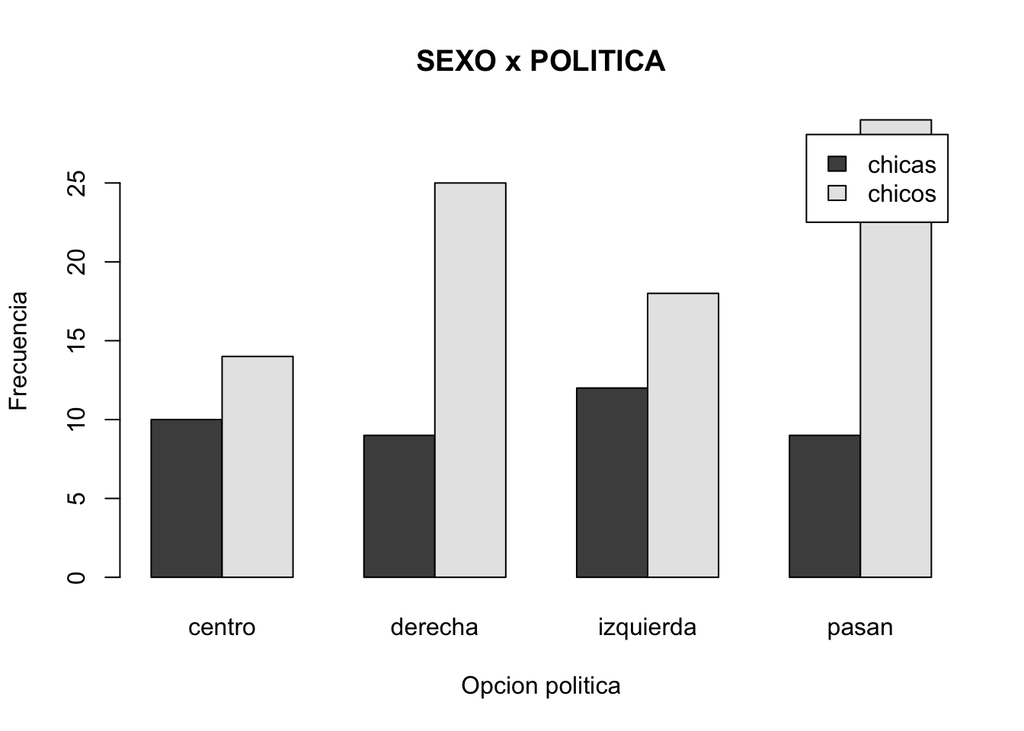

```r
barplot(tab_abs, beside = TRUE, legend = TRUE,
        main = "SEXO x POLITICA", xlab = "Opcion politica",
        ylab = "Frecuencia")
```

### Grafico de mosaico

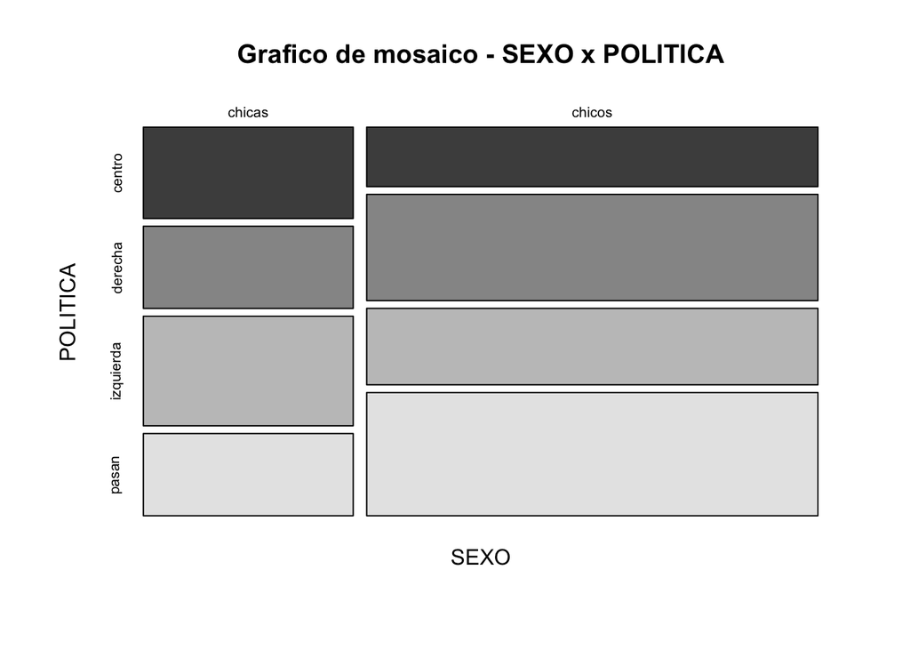

```r
mosaicplot(tab_abs, main = "Grafico de mosaico - SEXO x POLITICA",
           color = TRUE)
```

### Medida de asociacion: V de Cramer

```r
chi2 <- chisq.test(tab_abs)
n <- sum(tab_abs)
k <- min(nrow(tab_abs), ncol(tab_abs))
V_cramer <- sqrt(chi2$statistic / (n * (k - 1)))

cat("Chi-cuadrado:", round(chi2$statistic, 4), "\n")
```

```
## Chi-cuadrado: 3.6099
```

```r
cat("p-valor:", round(chi2$p.value, 4), "\n")
```

```
## p-valor: 0.3068
```

```r
cat("V de Cramer:", round(V_cramer, 4), "\n")
```

```
## V de Cramer: 0.1693
```

V de Cramer aproximadamente 0.17 indica una asociacion baja entre SEXO y POLITICA. Si miramos solo frecuencias absolutas parece que en todas las opciones hay mas chicos, pero es porque hay mas chicos en la muestra. Las frecuencias condicionales muestran que entre las chicas las opciones principales son izquierda y centro, mientras que entre los chicos hay mas de derecha y pasotas, aunque la diferencia no es muy grande.

# Parte 2: Analisis cuantitativa-cuantitativa

## Variables: ESTATURA, PESO y EDAD

### Diagrama de dispersion: ESTATURA vs PESO

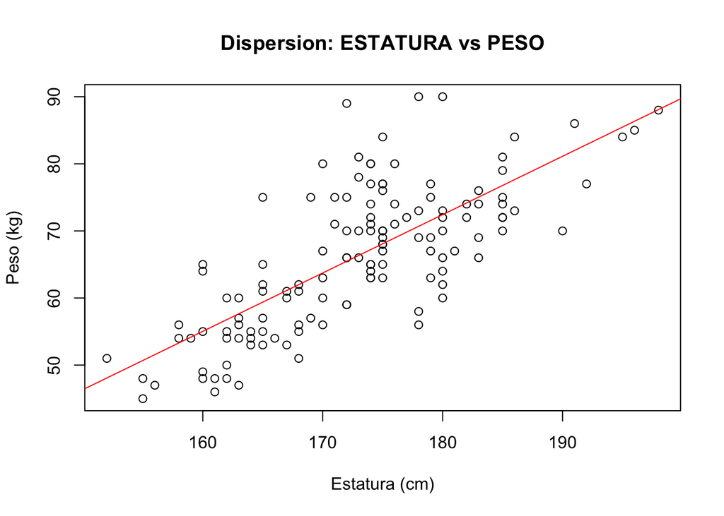

```r
plot(datos$ESTATURA, datos$PESO,
     main = "Dispersion: ESTATURA vs PESO",
     xlab = "Estatura (cm)", ylab = "Peso (kg)")
abline(lm(PESO ~ ESTATURA, data = datos), col = "red")
```

Ponemos ESTATURA en el eje X porque tiene mas sentido: una persona mas alta tiende a pesar mas, no al reves. La recta muestra una relacion positiva bastante clara.

### Covarianza y correlacion de Pearson

```r
datos_cc <- datos[!is.na(datos$ESTATURA) & !is.na(datos$PESO) & !is.na(datos$EDAD), ]

cat("--- ESTATURA vs PESO ---\n")
```

```
## --- ESTATURA vs PESO ---
```

```r
cat("Covarianza:", round(cov(datos_cc$ESTATURA, datos_cc$PESO), 3), "\n")
```

```
## Covarianza: 71.616
```

```r
cat("Correlacion r:", round(cor(datos_cc$ESTATURA, datos_cc$PESO), 4), "\n\n")
```

```
## Correlacion r: 0.7404
```

```r
cat("--- ESTATURA vs EDAD ---\n")
```

```
## --- ESTATURA vs EDAD ---
```

```r
cat("Covarianza:", round(cov(datos_cc$ESTATURA, datos_cc$EDAD), 3), "\n")
```

```
## Covarianza: 1.314
```

```r
cat("Correlacion r:", round(cor(datos_cc$ESTATURA, datos_cc$EDAD), 4), "\n\n")
```

```
## Correlacion r: 0.0868
```

```r
cat("--- PESO vs EDAD ---\n")
```

```
## --- PESO vs EDAD ---
```

```r
cat("Covarianza:", round(cov(datos_cc$PESO, datos_cc$EDAD), 3), "\n")
```

```
## Covarianza: 1.882
```

```r
cat("Correlacion r:", round(cor(datos_cc$PESO, datos_cc$EDAD), 4), "\n")
```

```
## Correlacion r: 0.1059
```

ESTATURA-PESO tiene una correlacion moderada-fuerte y positiva: a mayor estatura, mayor peso. ESTATURA-EDAD y PESO-EDAD tienen correlaciones casi nulas, lo cual tiene sentido porque en este rango de edad (19-32 anos) los jovenes ya no crecen ni engordan por la edad.

### Extension: ESTATURA vs EDAD y PESO vs EDAD

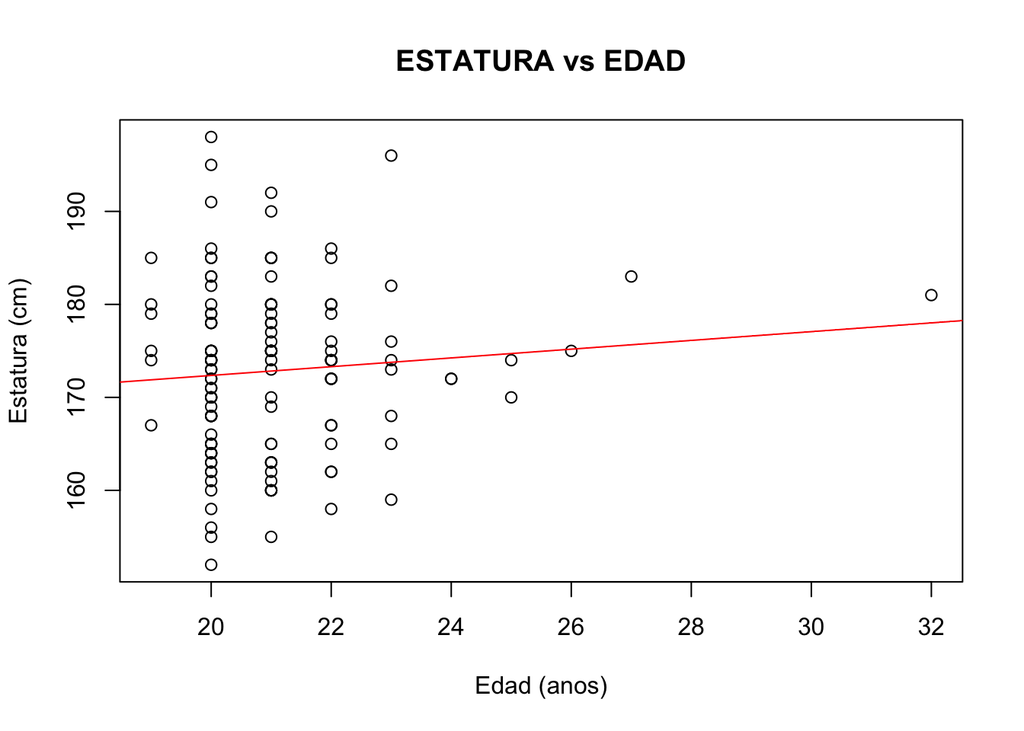

```r
plot(datos$EDAD, datos$ESTATURA,
     main = "ESTATURA vs EDAD",
     xlab = "Edad (anos)", ylab = "Estatura (cm)")
abline(lm(ESTATURA ~ EDAD, data = datos), col = "red")
```

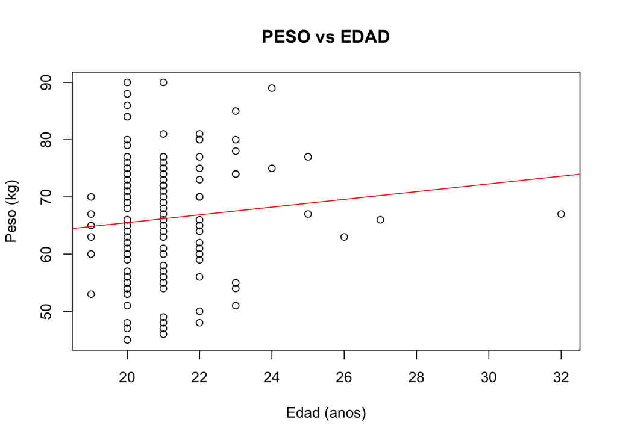

```r
plot(datos$EDAD, datos$PESO,
     main = "PESO vs EDAD",
     xlab = "Edad (anos)", ylab = "Peso (kg)")
abline(lm(PESO ~ EDAD, data = datos), col = "red")
```

### Matriz de correlaciones

```r
mat_cor <- cor(datos_cc[, c("ESTATURA", "PESO", "EDAD")], use = "complete.obs")
round(mat_cor, 4)
```

```
##          ESTATURA   PESO   EDAD
## ESTATURA   1.0000 0.7404 0.0868
## PESO       0.7404 1.0000 0.1059
## EDAD       0.0868 0.1059 1.0000
```

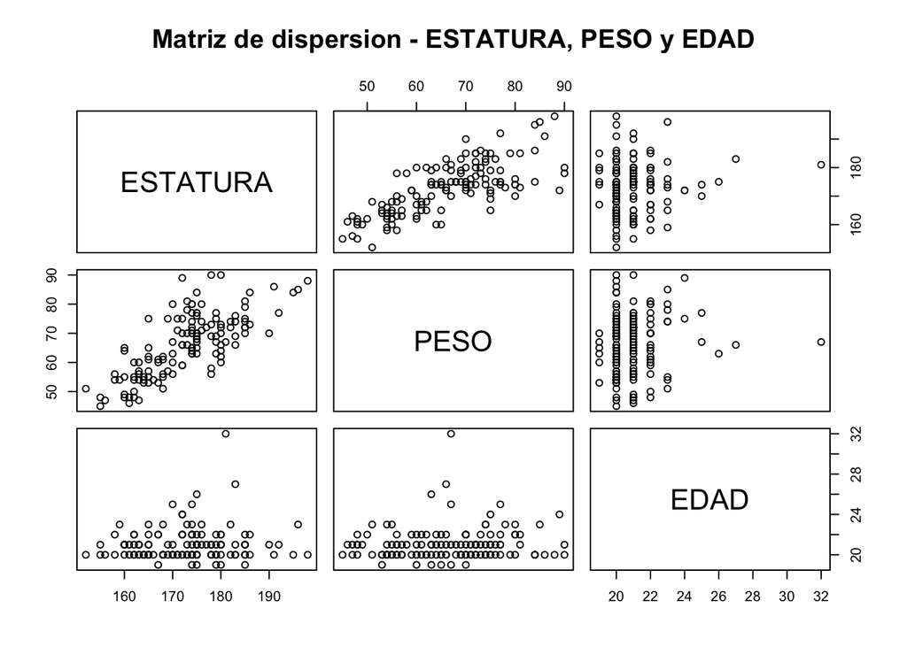

```r
pairs(datos_cc[, c("ESTATURA", "PESO", "EDAD")],
      main = "Matriz de dispersion - ESTATURA, PESO y EDAD")
```